# R 1st term project

aliya yakupova

1/8/2021

## Dataset descripton

For the project we will take database of **locations of Earthquakes off Fiji** (https://stat.ethz.ch/R-manual/R-devel/library/datasets/html/quakes.html)

The data set give the locations of 1000 seismic events of MB > 4.0. The events occurred in a cube near Fiji since 1964.

## Format

A data frame with 1000 observations on 5 variables.

1. lat numeric **Latitude of event**
2. long numeric **Longitude**
3. depth numeric **Depth (km)**
4. mag numeric **Richter Magnitude**
5. stations numeric **Number of stations reporting**

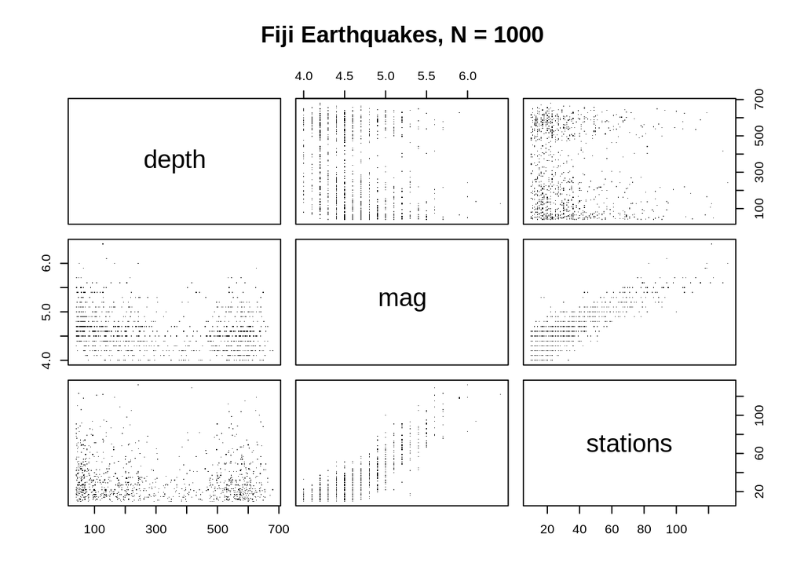

```r
str(quakes)
```

```
## 'data.frame':    1000 obs. of  5 variables:
##  $ lat     : num  -20.4 -20.6 -26 -18 -20.4 ...
##  $ long    : num  182 181 184 182 182 ...
##  $ depth   : int  562 650 42 626 649 195 82 194 211 622 ...
##  $ mag     : num  4.8 4.2 5.4 4.1 4 4 4.8 4.4 4.7 4.3 ...
##  $ stations: int  41 15 43 19 11 12 43 15 35 19 ...
```

```r
summary(quakes)
```

```
##       lat              long           depth            mag
##  Min.   :-38.59   Min.   :165.7   Min.   : 40.0   Min.   :4.00
##  1st Qu.:-23.47   1st Qu.:179.6   1st Qu.: 99.0   1st Qu.:4.30
##  Median :-20.30   Median :181.4   Median :247.0   Median :4.60
##  Mean   :-20.64   Mean   :179.5   Mean   :311.4   Mean   :4.62
##  3rd Qu.:-17.64   3rd Qu.:183.2   3rd Qu.:543.0   3rd Qu.:4.90
##  Max.   :-10.72   Max.   :188.1   Max.   :680.0   Max.   :6.40
##     stations
##  Min.   : 10.00
##  1st Qu.: 18.00
##  Median : 27.00
##  Mean   : 33.42
##  3rd Qu.: 42.00
##  Max.   :132.00
```

```r
sum(is.na(quakes))
```

```
## [1] 0
```

As we see there are no NA and all types are proper.

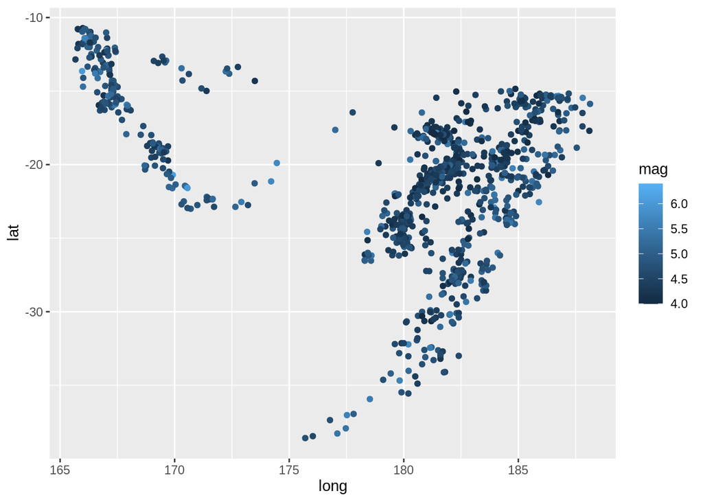

We can see that mostly earthquakes took a place at longitude 176 – 186 and latitude -30 – -15

Now let’s have a look at correlation of magnitude and depth.

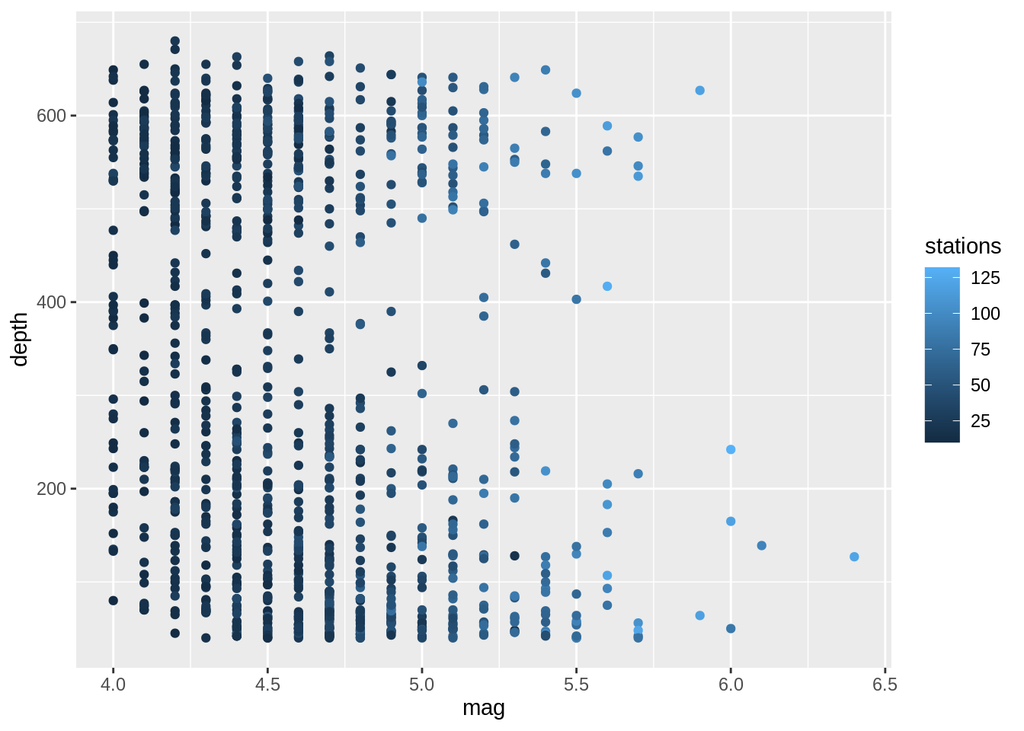

Now have a look how many stations detected earthquake respectively to depth, separately for remarkable earthquakes and not according to magnitude bigger or equal to 5.

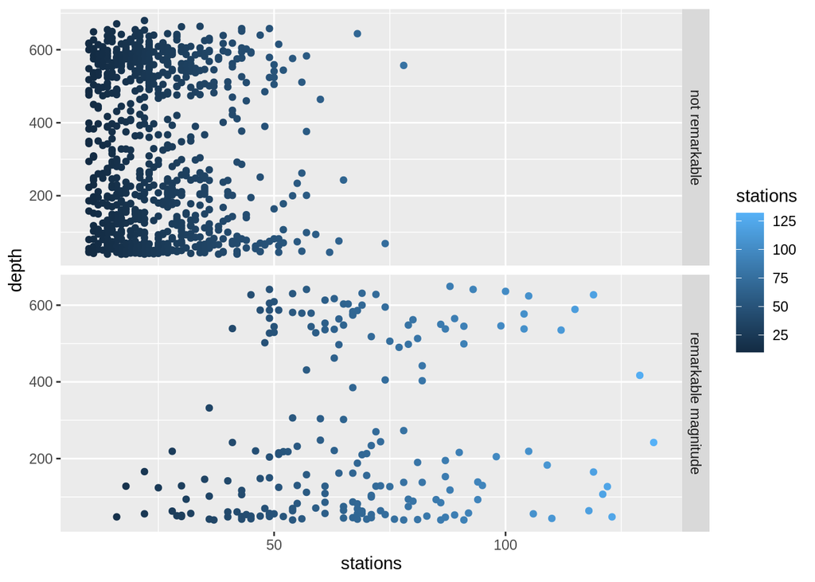

To see how depth and magnitude correlates with detection of earthquake by station let’s plot their dependency.

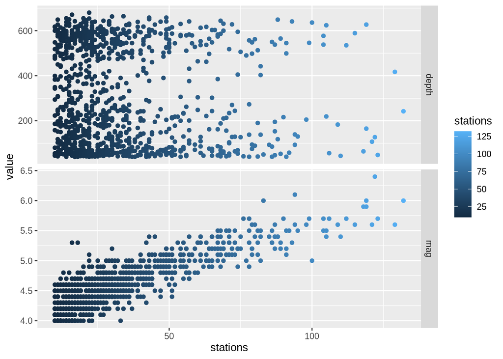

And we see that the higher magnitude the higher chance for detecting and with depth it doesn’t work.